# PROJECT-covid19-deathcase-analysis

Machine Learning Model for Predicting COVID-19 Patient Survival

The aim of this machine learning model is to predict whether a COVID-19 patient will survive or not based on their current symptoms, status, and medical history. The goal is to achieve an accuracy of 90% or higher.

Dataset Information:

```
The dataset contains 21 features.
It includes information for 1,048,575 unique patients.
In the Boolean features, the value 1 indicates "yes," and 2 indicates "no."
```

Features:

```
usmer: Indicates whether the patient received medical treatment at the first, second, or third level.
medical unit: Type of institution within the National Health System that provided the care.
sex: Gender of the patient.
patient type: Indicates whether the patient returned home or was hospitalized.
date died: If the patient died, it indicates the date of death; otherwise, it is set to "9999-99-99."
intubed: Indicates whether the patient was connected to a ventilator.
pneumonia: Indicates whether the patient already had air sac inflammation.
age: Age of the patient.
pregnant: Indicates whether the patient is pregnant.
diabetes: Indicates whether the patient has diabetes.
copd: Indicates whether the patient has Chronic Obstructive Pulmonary Disease (COPD).
asthma: Indicates whether the patient has asthma.
inmsupr: Indicates whether the patient is immunosuppressed.
hypertension: Indicates whether the patient has hypertension.
other disease: Indicates whether the patient has other diseases.
cardiovascular: Indicates whether the patient has heart or blood vessel-related diseases.
obesity: Indicates whether the patient is obese.
renal chronic: Indicates whether the patient has chronic renal disease.
tobacco: Indicates whether the patient is a tobacco user.
classification: COVID-19 test findings. Values 1-3 indicate different degrees of COVID-19 diagnosis, while 4 or higher means the patient is not a carrier or the test is inconclusive.
icu: Indicates whether the patient had been admitted to an Intensive Care Unit (ICU).
```

```python
import numpy as np
import pandas as pd
import seaborn as sns
import matplotlib.pyplot as plt
from sklearn.preprocessing import OrdinalEncoder
from sklearn.model_selection import train_test_split
from sklearn.metrics import confusion_matrix
import xgboost as xgb
from sklearn.ensemble import RandomForestClassifier
from sklearn.linear_model import SGDClassifier
from sklearn.metrics import accuracy_score
from imblearn.over_sampling import SMOTE
from sklearn.model_selection import GridSearchCV
from imblearn.under_sampling import RandomUnderSampler
```

```python
df = pd.read_csv("../datasets/covid19.csv")
```

```python
df.head()
```

|  | USMER | MEDICAL_UNIT | SEX | PATIENT_TYPE | DATE_DIED | INTUBED | PNEUMONIA | AGE | PREGNANT | DIABETES | ... | ASTHMA | INMSUPR | HIPERTENSION | OTHER_DISEASE | CARDIOVASCULAR | OBESITY | RENAL_CHRONIC | TOBACCO | CLASIFFICATION_FINAL | ICU |
| --- | --- | --- | --- | --- | --- | --- | --- | --- | --- | --- | --- | --- | --- | --- | --- | --- | --- | --- | --- | --- | --- |
| 0 | 2 | 1 | female | returned home | 03/05/2020 | NaN | 1.0 | 65 | 2.0 | 2.0 | ... | 2.0 | 2.0 | 1.0 | 2.0 | 2.0 | 2.0 | 2.0 | 2.0 | 3 | NaN |
| 1 | 2 | 1 | male | returned home | 03/06/2020 | NaN | 1.0 | 72 | NaN | 2.0 | ... | 2.0 | 2.0 | 1.0 | 2.0 | 2.0 | 1.0 | 1.0 | 2.0 | 5 | NaN |
| 2 | 2 | 1 | male | hospitalization | 09/06/2020 | 1.0 | 2.0 | 55 | NaN | 1.0 | ... | 2.0 | 2.0 | 2.0 | 2.0 | 2.0 | 2.0 | 2.0 | 2.0 | 3 | 2.0 |
| 3 | 2 | 1 | female | returned home | 12/06/2020 | NaN | 2.0 | 53 | 2.0 | 2.0 | ... | 2.0 | 2.0 | 2.0 | 2.0 | 2.0 | 2.0 | 2.0 | 2.0 | 7 | NaN |
| 4 | 2 | 1 | male | returned home | 21/06/2020 | NaN | 2.0 | 68 | NaN | 1.0 | ... | 2.0 | 2.0 | 1.0 | 2.0 | 2.0 | 2.0 | 2.0 | 2.0 | 3 | NaN |

5 rows × 21 columns

# EDA - Exploratory Data Analysis

### 1. Technical EDA

```python
df.dtypes
```

```
USMER                     int64
MEDICAL_UNIT              int64
SEX                      object
PATIENT_TYPE             object
DATE_DIED                object
INTUBED                 float64
PNEUMONIA               float64
AGE                       int64
PREGNANT                float64
DIABETES                float64
COPD                    float64
ASTHMA                  float64
INMSUPR                 float64
HIPERTENSION            float64
OTHER_DISEASE           float64
CARDIOVASCULAR          float64
OBESITY                 float64
RENAL_CHRONIC           float64
TOBACCO                 float64
CLASIFFICATION_FINAL      int64
ICU                     float64
dtype: object
```

##### ==> The majority of the values are in numeric format. Only sex, patient_type and date_died might require encoding

```python
df.nunique()
```

```
USMER                     2
MEDICAL_UNIT             13
SEX                       2
PATIENT_TYPE              2
DATE_DIED               401
INTUBED                   2
PNEUMONIA                 2
AGE                     121
PREGNANT                  2
DIABETES                  2
COPD                      2
ASTHMA                    2
INMSUPR                   2
HIPERTENSION              2
OTHER_DISEASE             2
CARDIOVASCULAR            2
OBESITY                   2
RENAL_CHRONIC             2
TOBACCO                   2
CLASIFFICATION_FINAL      7
ICU                       2
dtype: int64
```

##### ==> sex and patient_type have only two unique values that will be easily encoded. Date_died will require special treatment

```python
df.isnull().sum()
```

```
USMER                        0
MEDICAL_UNIT                 0
SEX                          0
PATIENT_TYPE                 0
DATE_DIED                    0
INTUBED                 855869
PNEUMONIA                16003
AGE                          0
PREGNANT                527265
DIABETES                  3338
COPD                      3003
ASTHMA                    2979
INMSUPR                   3404
HIPERTENSION              3104
OTHER_DISEASE             5045
CARDIOVASCULAR            3076
OBESITY                   3032
RENAL_CHRONIC             3006
TOBACCO                   3220
CLASIFFICATION_FINAL         0
ICU                     856032
dtype: int64
```

##### ==> a lot of null values that will need to be resolved

```python
alive_count = df[df['DATE_DIED']=='9999-99-99'].shape[0]
```

```python
dead_count = df[df['DATE_DIED']!='9999-99-99'].shape[0]
```

```python
total_count = df.shape[0]
```

```python
dead_count/total_count
```

```
0.07337767923133777
```

##### ==> Dataset seems to be unbalanced

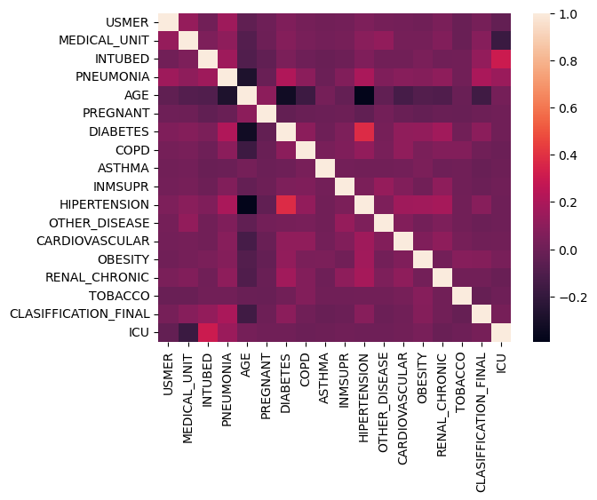

```python
sns.heatmap(df.corr())
```

##### ==> diabetes and hipertension shows average correlation

### 2. Interpretive EDA

##### Checking age distribution

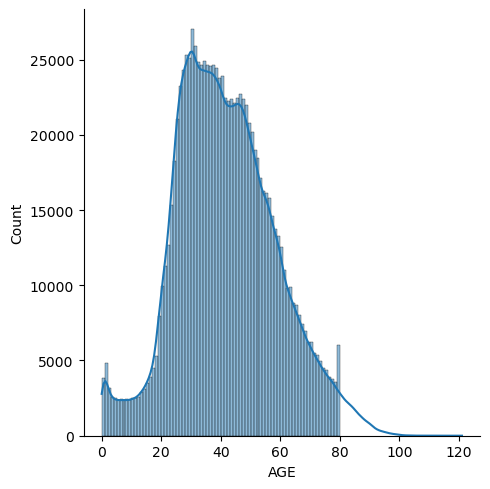

```python
a = sns.displot(df['AGE'].dropna(), bins=range(0,81,1), kde=True)
plt.show()
```

##### Survival distribution across age

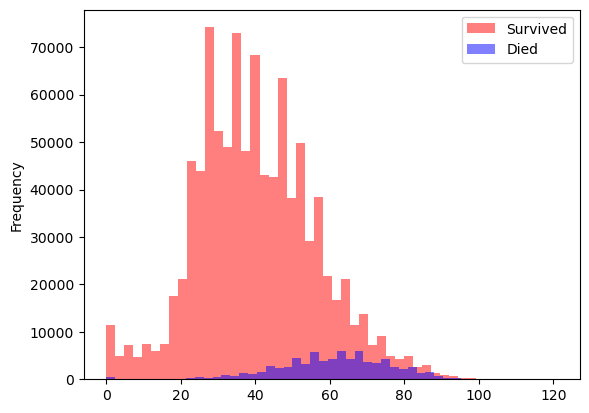

```python
survived = df[df['DATE_DIED']=='9999-99-99']
died = df[df['DATE_DIED']!='9999-99-99']

survived['AGE'].plot.hist(alpha=0.5, color='red', bins=50) # alpha - transperancy, bins - in how many intervals the age divided
died["AGE"].plot.hist(alpha=0.5, color='blue', bins=50)

plt.legend(['Survived', 'Died'])
plt.show()
```

```python
died["AGE"].describe()
```

```
count    76942.000000
mean        61.068545
std         15.366451
min          0.000000
25%         52.000000
50%         62.000000
75%         72.000000
max        119.000000
Name: AGE, dtype: float64
```

```python
survived["AGE"].describe()
```

```
count    971633.000000
mean         40.267791
std          16.063928
min           0.000000
25%          29.000000
50%          39.000000
75%          50.000000
max         121.000000
Name: AGE, dtype: float64
```

##### Insights

- Average age of of people who died is 61 years.
- Average age of people who survived is 40 years.
- 75% of survived people had less than 50 years.
- 75% of people who died had less than 72 years.

##### Some data processing to plot distribution of the target value

```python
for index, value in df['DATE_DIED'].iteritems():
    if value == '9999-99-99':
        df.at[index, 'DIED'] = 0
    else: df.at[index, 'DIED'] = 1
    # 0 - no, 1 - yes
```

```python
df.head()
```

|  | USMER | MEDICAL_UNIT | SEX | PATIENT_TYPE | DATE_DIED | INTUBED | PNEUMONIA | AGE | PREGNANT | DIABETES | ... | INMSUPR | HIPERTENSION | OTHER_DISEASE | CARDIOVASCULAR | OBESITY | RENAL_CHRONIC | TOBACCO | CLASIFFICATION_FINAL | ICU | DIED |
| --- | --- | --- | --- | --- | --- | --- | --- | --- | --- | --- | --- | --- | --- | --- | --- | --- | --- | --- | --- | --- | --- |
| 0 | 2 | 1 | female | returned home | 03/05/2020 | NaN | 1.0 | 65 | 2.0 | 2.0 | ... | 2.0 | 1.0 | 2.0 | 2.0 | 2.0 | 2.0 | 2.0 | 3 | NaN | 1.0 |
| 1 | 2 | 1 | male | returned home | 03/06/2020 | NaN | 1.0 | 72 | NaN | 2.0 | ... | 2.0 | 1.0 | 2.0 | 2.0 | 1.0 | 1.0 | 2.0 | 5 | NaN | 1.0 |
| 2 | 2 | 1 | male | hospitalization | 09/06/2020 | 1.0 | 2.0 | 55 | NaN | 1.0 | ... | 2.0 | 2.0 | 2.0 | 2.0 | 2.0 | 2.0 | 2.0 | 3 | 2.0 | 1.0 |
| 3 | 2 | 1 | female | returned home | 12/06/2020 | NaN | 2.0 | 53 | 2.0 | 2.0 | ... | 2.0 | 2.0 | 2.0 | 2.0 | 2.0 | 2.0 | 2.0 | 7 | NaN | 1.0 |
| 4 | 2 | 1 | male | returned home | 21/06/2020 | NaN | 2.0 | 68 | NaN | 1.0 | ... | 2.0 | 1.0 | 2.0 | 2.0 | 2.0 | 2.0 | 2.0 | 3 | NaN | 1.0 |

5 rows × 22 columns

#### ==> standart scaler is not required because values are in similar scales

#### Visualization of unbalanced dataset

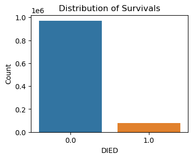

```python
Class = df['DIED'].value_counts()

plt.figure(figsize=(4, 3))  # Adjust the figsize as desired

sns.barplot(data=df, x=Class.index, y=Class.values)

plt.xlabel('DIED')
plt.ylabel('Count')
plt.title('Distribution of Survivals')

plt.show()
```

```python
Class
```

```
0.0    971633
1.0     76942
Name: DIED, dtype: int64
```

# Preprocessing

##### Needed preprocessing

- 1) resolve NaN values
- 2) encode sex, patient_type columns
- 3) drop date_died because we have a derived DIED column from it

##### 1) replace NaN values with zeros because we have too many NaN values and removing them would result in significantly smaller dataset

```python
df = df.fillna(0)
```

```python
df
```

|  | USMER | MEDICAL_UNIT | SEX | PATIENT_TYPE | DATE_DIED | INTUBED | PNEUMONIA | AGE | PREGNANT | DIABETES | ... | INMSUPR | HIPERTENSION | OTHER_DISEASE | CARDIOVASCULAR | OBESITY | RENAL_CHRONIC | TOBACCO | CLASIFFICATION_FINAL | ICU | DIED |
| --- | --- | --- | --- | --- | --- | --- | --- | --- | --- | --- | --- | --- | --- | --- | --- | --- | --- | --- | --- | --- | --- |
| 0 | 2 | 1 | female | returned home | 03/05/2020 | 0.0 | 1.0 | 65 | 2.0 | 2.0 | ... | 2.0 | 1.0 | 2.0 | 2.0 | 2.0 | 2.0 | 2.0 | 3 | 0.0 | 1.0 |
| 1 | 2 | 1 | male | returned home | 03/06/2020 | 0.0 | 1.0 | 72 | 0.0 | 2.0 | ... | 2.0 | 1.0 | 2.0 | 2.0 | 1.0 | 1.0 | 2.0 | 5 | 0.0 | 1.0 |
| 2 | 2 | 1 | male | hospitalization | 09/06/2020 | 1.0 | 2.0 | 55 | 0.0 | 1.0 | ... | 2.0 | 2.0 | 2.0 | 2.0 | 2.0 | 2.0 | 2.0 | 3 | 2.0 | 1.0 |
| 3 | 2 | 1 | female | returned home | 12/06/2020 | 0.0 | 2.0 | 53 | 2.0 | 2.0 | ... | 2.0 | 2.0 | 2.0 | 2.0 | 2.0 | 2.0 | 2.0 | 7 | 0.0 | 1.0 |
| 4 | 2 | 1 | male | returned home | 21/06/2020 | 0.0 | 2.0 | 68 | 0.0 | 1.0 | ... | 2.0 | 1.0 | 2.0 | 2.0 | 2.0 | 2.0 | 2.0 | 3 | 0.0 | 1.0 |
| ... | ... | ... | ... | ... | ... | ... | ... | ... | ... | ... | ... | ... | ... | ... | ... | ... | ... | ... | ... | ... | ... |
| 1048570 | 2 | 13 | male | returned home | 9999-99-99 | 0.0 | 2.0 | 40 | 0.0 | 2.0 | ... | 2.0 | 2.0 | 2.0 | 2.0 | 2.0 | 2.0 | 2.0 | 7 | 0.0 | 0.0 |
| 1048571 | 1 | 13 | male | hospitalization | 9999-99-99 | 2.0 | 2.0 | 51 | 0.0 | 2.0 | ... | 2.0 | 1.0 | 2.0 | 2.0 | 2.0 | 2.0 | 2.0 | 7 | 2.0 | 0.0 |
| 1048572 | 2 | 13 | male | returned home | 9999-99-99 | 0.0 | 2.0 | 55 | 0.0 | 2.0 | ... | 2.0 | 2.0 | 2.0 | 2.0 | 2.0 | 2.0 | 2.0 | 7 | 0.0 | 0.0 |
| 1048573 | 2 | 13 | male | returned home | 9999-99-99 | 0.0 | 2.0 | 28 | 0.0 | 2.0 | ... | 2.0 | 2.0 | 2.0 | 2.0 | 2.0 | 2.0 | 2.0 | 7 | 0.0 | 0.0 |
| 1048574 | 2 | 13 | male | returned home | 9999-99-99 | 0.0 | 2.0 | 52 | 0.0 | 2.0 | ... | 2.0 | 2.0 | 2.0 | 2.0 | 2.0 | 2.0 | 2.0 | 7 | 0.0 | 0.0 |

1048575 rows × 22 columns

##### 2) encode sex, patient_type columns

```python
columns_to_encode = ['SEX', 'PATIENT_TYPE']
enc = OrdinalEncoder()
df[columns_to_encode] = enc.fit_transform(df[columns_to_encode])
```

##### 3) drop DATE_DIED because we have a derived DIED column from it

```python
df = df.drop(['DATE_DIED'], axis=1)
```

```python
df.head()
```

|  | USMER | MEDICAL_UNIT | SEX | PATIENT_TYPE | INTUBED | PNEUMONIA | AGE | PREGNANT | DIABETES | COPD | ... | INMSUPR | HIPERTENSION | OTHER_DISEASE | CARDIOVASCULAR | OBESITY | RENAL_CHRONIC | TOBACCO | CLASIFFICATION_FINAL | ICU | DIED |
| --- | --- | --- | --- | --- | --- | --- | --- | --- | --- | --- | --- | --- | --- | --- | --- | --- | --- | --- | --- | --- | --- |
| 0 | 2 | 1 | 0.0 | 1.0 | 0.0 | 1.0 | 65 | 2.0 | 2.0 | 2.0 | ... | 2.0 | 1.0 | 2.0 | 2.0 | 2.0 | 2.0 | 2.0 | 3 | 0.0 | 1.0 |
| 1 | 2 | 1 | 1.0 | 1.0 | 0.0 | 1.0 | 72 | 0.0 | 2.0 | 2.0 | ... | 2.0 | 1.0 | 2.0 | 2.0 | 1.0 | 1.0 | 2.0 | 5 | 0.0 | 1.0 |
| 2 | 2 | 1 | 1.0 | 0.0 | 1.0 | 2.0 | 55 | 0.0 | 1.0 | 2.0 | ... | 2.0 | 2.0 | 2.0 | 2.0 | 2.0 | 2.0 | 2.0 | 3 | 2.0 | 1.0 |
| 3 | 2 | 1 | 0.0 | 1.0 | 0.0 | 2.0 | 53 | 2.0 | 2.0 | 2.0 | ... | 2.0 | 2.0 | 2.0 | 2.0 | 2.0 | 2.0 | 2.0 | 7 | 0.0 | 1.0 |
| 4 | 2 | 1 | 1.0 | 1.0 | 0.0 | 2.0 | 68 | 0.0 | 1.0 | 2.0 | ... | 2.0 | 1.0 | 2.0 | 2.0 | 2.0 | 2.0 | 2.0 | 3 | 0.0 | 1.0 |

5 rows × 21 columns

### Idea

We can employ oversampling now to make data more balanced but it is important to check the base case scenario, so it is going to be done later after running basic training and prediction

# Training

##### Classification exercise. Algorihtms to be considered

- XGBoost
- Random Forest Classifier
- SVC => after some reaserch SVC might take too long to train on dataset that has about 1 million of rows as it has quadratic time compexity, so the alternative will be Stochastic Gradient Descent (SGD) Classifier

## Split

```python
y = df['DIED'].astype(int)
X = df.drop(['DIED'], axis=1)
X_train, X_test, y_train, y_test = train_test_split(X, y, test_size=0.2, random_state=21, stratify=y)
```

## XGBoost

```python
xgb_c = xgb.XGBRFClassifier(random_state=22)
xgb_model = xgb_c.fit(X_train, y_train, verbose=False)
xgb_score = xgb_model.score(X_test, y_test)
print('test accuracy: ', xgb_score)
```

```
test accuracy:  0.9495982643110888
```

```python
test_predictions = xgb_c.predict(X_test)
confusion_matrix(y_test, test_predictions)
```

```
array([[191581,   2746],
       [  7824,   7564]], dtype=int64)
```

## Random Forest Classifier

```python
rf = RandomForestClassifier(random_state=42)
rf_model = rf.fit(X_train, y_train)
```

```python
rf_pred = rf_model.predict(X_test)
rf_pred_score = accuracy_score(y_test, rf_pred)
print("Random Forest accuracy:", accuracy_score(y_test, rf_pred))
```

```
Random Forest accuracy: 0.944410271082183
```

```python
confusion_matrix(y_test, rf_pred)
```

```
array([[189749,   4578],
       [  7080,   8308]], dtype=int64)
```

## SGDClassifier

```python
sgd = SGDClassifier(random_state=42)
```

```python
sgd_model = sgd.fit(X_train, y_train)
```

```python
sgd_pred = sgd_model.predict(X_test)
```

```python
sgd_pred_score = accuracy_score(y_test, sgd_pred)
```

##### Displaying table of accuracy score results

```python
data = {
    'Model': ['XGBoost', 'RFC', 'SGD'],
    'Accuracy score': [
        xgb_c.score(X_test, y_test),
        accuracy_score(y_test, rf_pred),
        accuracy_score(y_test, sgd_pred)
    ]
}

pd.DataFrame(data)
```

|  | Model | Accuracy score |
| --- | --- | --- |
| 0 | XGBoost | 0.949598 |
| 1 | RFC | 0.944410 |
| 2 | SGD | 0.935021 |

#### Let's experiment with some oversampling

```python
sm = SMOTE(random_state=22, sampling_strategy=0.12) # previously ratio was 0.07
X_train_res, y_train_res = sm.fit_resample(X_train, y_train)
```

### run training again with XGBoost

```python
xgb_res = xgb_c.fit(X_train_res, y_train_res)
```

```python
xgb_res_score = xgb_res.score(X_test, y_test)
print('XGBoost test accuracy after oversampling: ', xgb_res_score)
```

```
XGBoost test accuracy after oversampling:  0.9465798822211096
```

### run training again with RFC

```python
rf_res = rf.fit(X_train_res, y_train_res)
rf_pred_res = rf_res.predict(X_test)
rf_pred_res_score = accuracy_score(y_test, rf_pred_res)
print("Random Forest accuracy after oversampling:", rf_pred_res_score)
```

```
Random Forest accuracy after oversampling: 0.9427318026845958
```

### run training again with SGD

```python
sgd_res = sgd.fit(X_train_res, y_train_res)
```

```python
sgd_pred_res = sgd.predict(X_test)
```

```python
sgd_pred_res_score = accuracy_score(y_test, sgd_pred_res)
```

##### Table with end results of oversampling

```python
data = {
    'Model': ['XGBoost', 'RFC', 'SGD'],
    'Accuracy score': [
        xgb_score,
        rf_pred_score,
        sgd_pred_score
    ],
    'After oversampling': [
        xgb_res_score,
        rf_pred_res_score,
        sgd_pred_res_score
    ],
    'Change': [
        xgb_res_score - xgb_score,
        rf_pred_res_score - rf_pred_score,
        sgd_pred_res_score - sgd_pred_score,
    ]
}

pd.DataFrame(data)
```

|  | Model | Accuracy score | After oversampling | Change |
| --- | --- | --- | --- | --- |
| 0 | XGBoost | 0.949598 | 0.946580 | -0.003018 |
| 1 | RFC | 0.944410 | 0.942732 | -0.001678 |
| 2 | SGD | 0.935021 | 0.936199 | 0.001178 |

## Get the importance of each feature

```python
importance_scores = xgb_model.feature_importances_
feature_names = X_train.columns
```

```python
sorted_indices = importance_scores.argsort()[::-1]
sorted_scores = importance_scores[sorted_indices]
sorted_features = feature_names[sorted_indices]
```

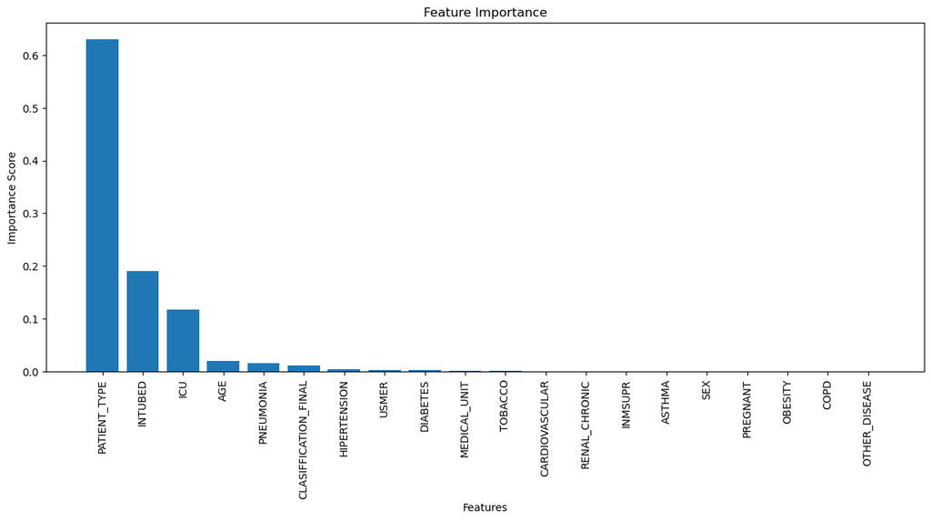

```python
plt.figure(figsize=(15, 6))
plt.bar(range(len(sorted_scores)), sorted_scores, tick_label=sorted_features)
plt.xticks(rotation=90)
plt.xlabel('Features')
plt.ylabel('Importance Score')
plt.title('Feature Importance')
plt.show()
```

```python
sorted_scores
```

```
array([6.2987763e-01, 1.9045393e-01, 1.1805581e-01, 1.9742483e-02,
       1.5109948e-02, 1.1119973e-02, 4.7146557e-03, 2.6800705e-03,
       2.4255824e-03, 1.8720088e-03, 7.0700998e-04, 5.9298112e-04,
       5.4513011e-04, 4.9566140e-04, 4.2314420e-04, 3.5191496e-04,
       3.2413739e-04, 2.6683530e-04, 1.2151147e-04, 1.1954844e-04],
      dtype=float32)
```

```python
sorted_features
```

```
Index(['PATIENT_TYPE', 'INTUBED', 'ICU', 'AGE', 'PNEUMONIA',
       'CLASIFFICATION_FINAL', 'HIPERTENSION', 'USMER', 'DIABETES',
       'MEDICAL_UNIT', 'TOBACCO', 'CARDIOVASCULAR', 'RENAL_CHRONIC', 'INMSUPR',
       'ASTHMA', 'SEX', 'PREGNANT', 'OBESITY', 'COPD', 'OTHER_DISEASE'],
      dtype='object')
```

```python
pd.DataFrame({
    'Feature': sorted_features,
    'Importance score': sorted_scores
})
```

|  | Feature | Importance score |
| --- | --- | --- |
| 0 | PATIENT_TYPE | 0.629878 |
| 1 | INTUBED | 0.190454 |
| 2 | ICU | 0.118056 |
| 3 | AGE | 0.019742 |
| 4 | PNEUMONIA | 0.015110 |
| 5 | CLASIFFICATION_FINAL | 0.011120 |
| 6 | HIPERTENSION | 0.004715 |
| 7 | USMER | 0.002680 |
| 8 | DIABETES | 0.002426 |
| 9 | MEDICAL_UNIT | 0.001872 |
| 10 | TOBACCO | 0.000707 |
| 11 | CARDIOVASCULAR | 0.000593 |
| 12 | RENAL_CHRONIC | 0.000545 |
| 13 | INMSUPR | 0.000496 |
| 14 | ASTHMA | 0.000423 |
| 15 | SEX | 0.000352 |
| 16 | PREGNANT | 0.000324 |
| 17 | OBESITY | 0.000267 |
| 18 | COPD | 0.000122 |
| 19 | OTHER_DISEASE | 0.000120 |

### Insight

After examining the importance of each feature, ['TOBACCO', 'CARDIOVASCULAR', 'RENAL_CHRONIC', 'INMSUPR', 'ASTHMA', 'SEX', 'PREGNANT', 'OBESITY', 'COPD', 'OTHER_DISEASE'] showed really low siginificance on the prediction model ==> remove them to save training and optimization time or even achieve better results due to less distractions for the training model

```python
df_min = df.drop(['TOBACCO', 'CARDIOVASCULAR', 'RENAL_CHRONIC', 'INMSUPR',
       'ASTHMA', 'SEX', 'PREGNANT', 'OBESITY', 'COPD', 'OTHER_DISEASE'], axis=1)
```

```python
y_min = df_min['DIED'].astype(int)
X_min = df_min.drop(['DIED'], axis=1)
X_train_min, X_test_min, y_train_min, y_test_min = train_test_split(X_min, y_min, test_size=0.2, random_state=21, stratify=y)
```

```python
xgb_c_min = xgb.XGBRFClassifier(random_state=22)
xgb_model_min = xgb_c_min.fit(X_train_min, y_train_min, verbose=False)
xgb_score_min = xgb_model_min.score(X_test_min, y_test_min)
print('test accuracy: ', xgb_score_min)
```

```
test accuracy:  0.9496793267052905
```

```python
df_min.head()
```

|  | USMER | MEDICAL_UNIT | PATIENT_TYPE | INTUBED | PNEUMONIA | AGE | DIABETES | HIPERTENSION | CLASIFFICATION_FINAL | ICU | DIED |
| --- | --- | --- | --- | --- | --- | --- | --- | --- | --- | --- | --- |
| 0 | 2 | 1 | 1.0 | 0.0 | 1.0 | 65 | 2.0 | 1.0 | 3 | 0.0 | 1.0 |
| 1 | 2 | 1 | 1.0 | 0.0 | 1.0 | 72 | 2.0 | 1.0 | 5 | 0.0 | 1.0 |
| 2 | 2 | 1 | 0.0 | 1.0 | 2.0 | 55 | 1.0 | 2.0 | 3 | 2.0 | 1.0 |
| 3 | 2 | 1 | 1.0 | 0.0 | 2.0 | 53 | 2.0 | 2.0 | 7 | 0.0 | 1.0 |
| 4 | 2 | 1 | 1.0 | 0.0 | 2.0 | 68 | 1.0 | 1.0 | 3 | 0.0 | 1.0 |

```python
importance_scores_min = xgb_model_min.feature_importances_
feature_names_min = X_train_min.columns
```

```python
sorted_indices_min = importance_scores_min.argsort()[::-1]
sorted_scores_min = importance_scores_min[sorted_indices_min]
sorted_features_min = feature_names_min[sorted_indices_min]
```

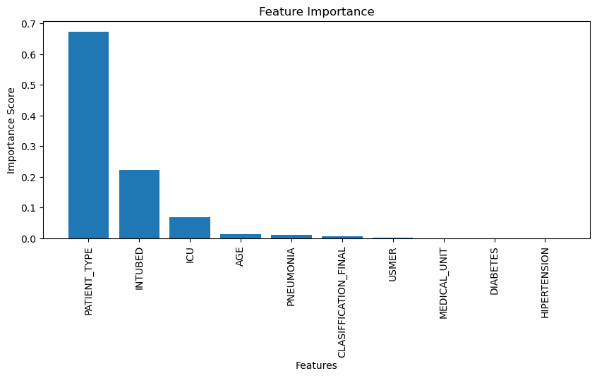

```python
plt.figure(figsize=(10, 4))
plt.bar(range(len(sorted_scores_min)), sorted_scores_min, tick_label=sorted_features_min)
plt.xticks(rotation=90)
plt.xlabel('Features')
plt.ylabel('Importance Score')
plt.title('Feature Importance')
plt.show()
```

```python
sorted_scores_min
```

```
array([6.7389810e-01, 2.2359285e-01, 6.7947805e-02, 1.2587040e-02,
       1.1389460e-02, 6.5300497e-03, 1.7971499e-03, 1.0736458e-03,
       7.0464256e-04, 4.7920737e-04], dtype=float32)
```

```python
sorted_features_min
```

```
Index(['PATIENT_TYPE', 'INTUBED', 'ICU', 'AGE', 'PNEUMONIA',
       'CLASIFFICATION_FINAL', 'USMER', 'MEDICAL_UNIT', 'DIABETES',
       'HIPERTENSION'],
      dtype='object')
```

#### Maybe hypertension is also redundant?

```python
df_min_2 = df.drop(['HIPERTENSION'], axis=1)
```

```python
y_min_2 = df_min_2['DIED'].astype(int)
X_min_2 = df_min_2.drop(['DIED'], axis=1)
X_train_min_2, X_test_min_2, y_train_min_2, y_test_min_2 = train_test_split(X_min_2, y_min_2, test_size=0.2, random_state=21, stratify=y)
```

```python
# xgb_c_min = xgb.XGBRFClassifier(random_state=22)
# xgb_model_min = xgb_c_min.fit(X_train_min, y_train_min, verbose=False)
# xgb_score_min = xgb_model_min.score(X_test_min, y_test_min)
# print('test accuracy: ', xgb_score_min)
```

[output not shown]

# == EXTRA EDA ==

#### Ploting data to see how certain conditions influence the rate of death

```python
# Make data copy
df_plot = df.copy()
```

```python
# Map values to boolean (True/False)
binary_columns = ['INTUBED', 'PNEUMONIA', 'DIABETES', 'HIPERTENSION', 'ICU', 'TOBACCO', 'OBESITY']
for column in binary_columns:
    df_plot[column] = df_plot[column].map({0: np.nan, 1: True, 2: False})
```

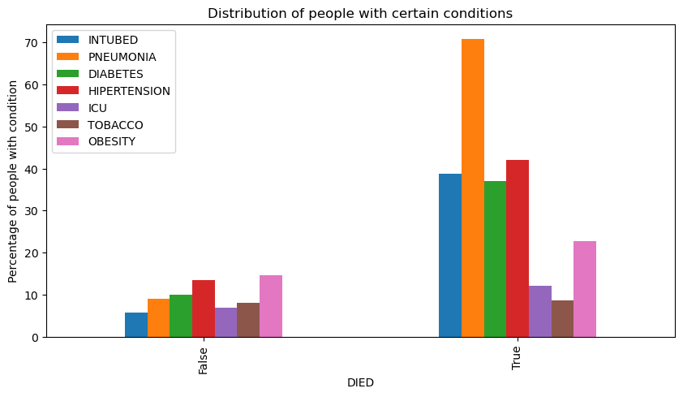

```python
# Group by "DIED" column and calculate the percentage of true values for each column
grouped = df_plot.groupby('DIED')[binary_columns].mean() * 100

ax = grouped.plot(kind='bar', figsize=(10, 5))

custom_labels = ['False', 'True']
ax.set_xticklabels(custom_labels)

# Create a bar plot
plt.xlabel('DIED')
plt.ylabel('Percentage of people with condition')
plt.title('Distribution of people with certain conditions')
plt.legend(loc='upper left')
plt.show()
```

##### Checking whether the tobacco consumers had higher rates of death

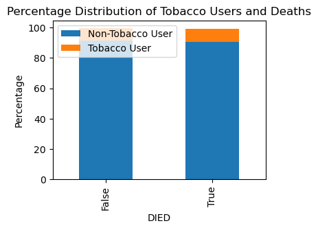

```python
# Group by "DIED" and "TOBACCO" columns and calculate the percentage of true values for each combination
grouped = (df_plot.groupby(['DIED', 'TOBACCO']).size() / df_plot.groupby('DIED').size()).unstack() * 100

# Create the stacked bar plot
ax = grouped.plot(kind='bar', stacked=True, figsize=(4, 3))

# Set the x-axis tick labels
ax.set_xticklabels(['False', 'True'])

# Set the plot labels and title
plt.xlabel('DIED')
plt.ylabel('Percentage')
plt.title('Percentage Distribution of Tobacco Users and Deaths')

# Display the legend and show the plot
plt.legend(['Non-Tobacco User', 'Tobacco User'], loc='upper left')
plt.show()
```

##### ==> Seems that tobacco usage didn't have a big effect on the chance of death

#### Now let's see what is the average age of death for both sexes

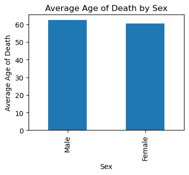

```python
# Filter the DataFrame to include only rows where individuals died
df_filtered = df_plot[df_plot['DIED'] == True]

# Group by 'DIED' and 'SEX' columns and calculate the average age of death for each combination
grouped = df_filtered.groupby('SEX')['AGE'].mean()

# Create the bar plot
ax = grouped.plot(kind='bar', figsize=(4, 3))

# Set the x-axis tick labels
ax.set_xticklabels(['Male', 'Female'])

# Set the plot labels and title
plt.xlabel('Sex')
plt.ylabel('Average Age of Death')
plt.title('Average Age of Death by Sex')

# Show the plot
plt.show()
```

##### ==> Average age of death by sex is approximately the same

#### Checking the conditions across different age groups

```python
def process_age(df, cut_points, label_names):
    df_age = df.copy()
    df_age['AGE'] = df_age['AGE'].fillna(-0.5)
    df_age['AGE_CATEGORIES'] = pd.cut(df_age['AGE'], cut_points, labels=label_names)
    return df_age
```

```python
cut_points = [-1, 0, 5, 12, 18, 35, 60, 121]
label_names = ['Missing', 'Infant', 'Child', 'Teenager', 'Young Adult', 'Adult', 'Senior']

df_age = process_age(df, cut_points, label_names)
```

```python
# Make data copy
df_age_plot = df_age.copy()
```

```python
# Map values to boolean (True/False)
binary_columns = [ 'ICU', 'PNEUMONIA', 'DIABETES', 'HIPERTENSION']
for column in binary_columns:
    df_age_plot[column] = df_age_plot[column].map({0: np.nan, 1: True, 2: False})
```

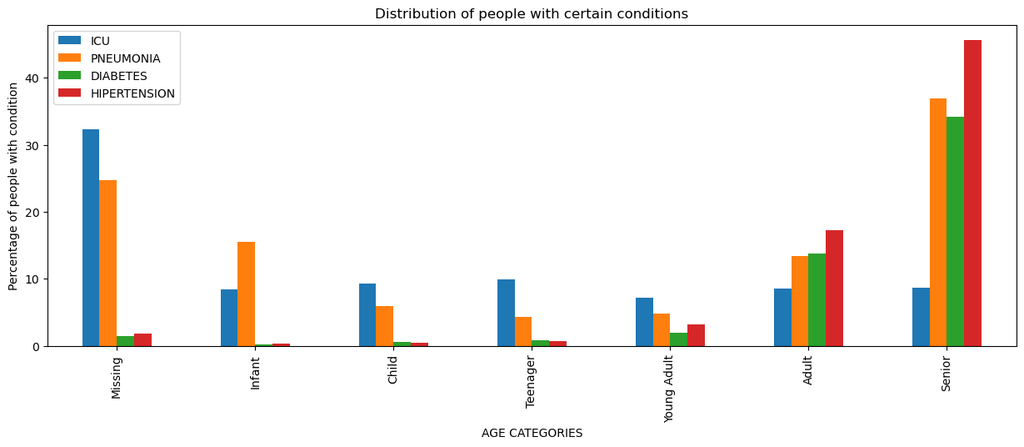

```python
# Group by "AGE_CATEGORIES" column and calculate the percentage of true values for each column
grouped = df_age_plot.groupby('AGE_CATEGORIES')[binary_columns].mean() * 100

ax = grouped.plot(kind='bar', figsize=(15, 5))
# Create a bar plot
plt.xlabel('AGE CATEGORIES')
plt.ylabel('Percentage of people with condition')
plt.title('Distribution of people with certain conditions')
plt.legend(loc='upper left')
plt.show()
```

##### ==> As expected higher rate of death in adults and seniors probably were caused by illnesses and other conditions

# Optimization

#### Things to consider

- Knowing that XGBoost gave the best base result, we will try to optimize it
- During optimization it is important to include base parameters

```python
xgb_model_min.get_params()
```

```
{'colsample_bynode': 0.8,
 'learning_rate': 1.0,
 'reg_lambda': 1e-05,
 'subsample': 0.8,
 'objective': 'binary:logistic',
 'use_label_encoder': None,
 'base_score': None,
 'booster': None,
 'callbacks': None,
 'colsample_bylevel': None,
 'colsample_bytree': None,
 'early_stopping_rounds': None,
 'enable_categorical': False,
 'eval_metric': None,
 'feature_types': None,
 'gamma': None,
 'gpu_id': None,
 'grow_policy': None,
 'importance_type': None,
 'interaction_constraints': None,
 'max_bin': None,
 'max_cat_threshold': None,
 'max_cat_to_onehot': None,
 'max_delta_step': None,
 'max_depth': None,
 'max_leaves': None,
 'min_child_weight': None,
 'missing': nan,
 'monotone_constraints': None,
 'n_estimators': 100,
 'n_jobs': None,
 'num_parallel_tree': None,
 'predictor': None,
 'random_state': 22,
 'reg_alpha': None,
 'sampling_method': None,
 'scale_pos_weight': None,
 'tree_method': None,
 'validate_parameters': None,
 'verbosity': None}
```

```python
#Define the parameter grid for hyperparameter search. Important to include current xgb_model's base parameters
param_grid = {
    'learning_rate': [1, 0.9, 0.8],
    'max_depth': [None, 2, 3],
    'n_estimators': [100, 200, 500]
}

grid_search = GridSearchCV(xgb_model_min, param_grid, cv=3, scoring='accuracy', n_jobs=-1)
grid_search.fit(X_train_min, y_train_min)

best_params = grid_search.best_params_
best_model = grid_search.best_estimator_

# Evaluate the best model on the test set
best_score = best_model.score(X_test_min, y_test_min)

# Print the best hyperparameters and model performance
print("Best Hyperparameters:", best_params)
print("Best Model Score:", best_score)
```

```
Best Hyperparameters: {'learning_rate': 1, 'max_depth': None, 'n_estimators': 100}
Best Model Score: 0.9496793267052905
```

```python
param_grid_2 = {
    'learning_rate': [1, 0.2, 0.1],
    'max_depth': [None, 2, 3, 5],  # acording to the creators going above 5 is rarely advised
    'n_estimators': [100, 200, 300],
}

grid_search_2 = GridSearchCV(xgb_model_min, param_grid, cv=3, scoring='accuracy', n_jobs=-1)
grid_search_2.fit(X_train_min, y_train_min)

best_params_2 = grid_search_2.best_params_
best_model_2 = grid_search_2.best_estimator_

best_score_2 = best_model_2.score(X_test_min, y_test_min)

print("Best Hyperparameters:", best_params_2)
print("Best Model Score:", best_score_2)
```

```
Best Hyperparameters: {'learning_rate': 1, 'max_depth': None, 'n_estimators': 100}
Best Model Score: 0.9496793267052905
```

##### ==> no serious ahievements were reached after optimization

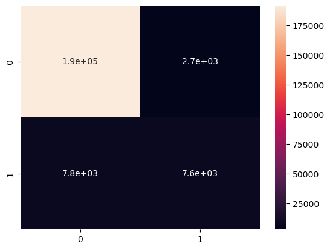

```python
test_predictions = best_model.predict(X_test_min)
cm = confusion_matrix(y_test, test_predictions)
sns.heatmap(cm, annot=True)
```

```python
cm
```

```
array([[191583,   2744],
       [  7809,   7579]], dtype=int64)
```

## What about correlation now?

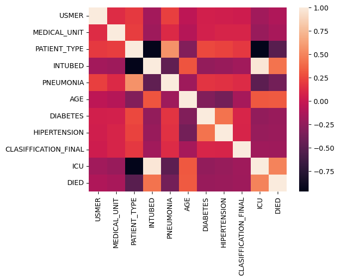

```python
sns.heatmap(df_min.corr())
```

```python
df_min.corr()
```

|  | USMER | MEDICAL_UNIT | PATIENT_TYPE | INTUBED | PNEUMONIA | AGE | DIABETES | HIPERTENSION | CLASIFFICATION_FINAL | ICU | DIED |
| --- | --- | --- | --- | --- | --- | --- | --- | --- | --- | --- | --- |
| USMER | 1.000000 | 0.127927 | 0.190570 | -0.169939 | 0.213391 | -0.045088 | 0.049919 | 0.047990 | 0.028840 | -0.175673 | -0.112671 |
| MEDICAL_UNIT | 0.127927 | 1.000000 | 0.205413 | -0.195279 | 0.116055 | -0.082223 | 0.063395 | 0.084270 | 0.079981 | -0.214996 | -0.149030 |
| PATIENT_TYPE | 0.190570 | 0.205413 | 1.000000 | -0.952396 | 0.559036 | -0.315193 | 0.250458 | 0.229903 | 0.183370 | -0.963993 | -0.515582 |
| INTUBED | -0.169939 | -0.195279 | -0.952396 | 1.000000 | -0.476610 | 0.299167 | -0.235915 | -0.214888 | -0.175733 | 0.972450 | 0.422331 |
| PNEUMONIA | 0.213391 | 0.116055 | 0.559036 | -0.476610 | 1.000000 | -0.192778 | 0.170428 | 0.150247 | 0.121063 | -0.488532 | -0.381977 |
| AGE | -0.045088 | -0.082223 | -0.315193 | 0.299167 | -0.192778 | 1.000000 | -0.321798 | -0.382671 | -0.152637 | 0.315663 | 0.320801 |
| DIABETES | 0.049919 | 0.063395 | 0.250458 | -0.235915 | 0.170428 | -0.321798 | 1.000000 | 0.418234 | 0.094151 | -0.243898 | -0.215319 |
| HIPERTENSION | 0.047990 | 0.084270 | 0.229903 | -0.214888 | 0.150247 | -0.382671 | 0.418234 | 1.000000 | 0.086537 | -0.224567 | -0.204921 |
| CLASIFFICATION_FINAL | 0.028840 | 0.079981 | 0.183370 | -0.175733 | 0.121063 | -0.152637 | 0.094151 | 0.086537 | 1.000000 | -0.188500 | -0.196085 |
| ICU | -0.175673 | -0.214996 | -0.963993 | 0.972450 | -0.488532 | 0.315663 | -0.243898 | -0.224567 | -0.188500 | 1.000000 | 0.490991 |
| DIED | -0.112671 | -0.149030 | -0.515582 | 0.422331 | -0.381977 | 0.320801 | -0.215319 | -0.204921 | -0.196085 | 0.490991 | 1.000000 |

#### ==> Difficult to asses. High correlation among PATIENT_TYPE, INTUBED and ICU but these features are the most important for prediction model...

## Some tests with undersampling

```python
rus = RandomUnderSampler(sampling_strategy=0.9, random_state=33)

X_train_under, y_train_under = rus.fit_resample(X_train, y_train)
```

```python
xgb_c_under = xgb.XGBRFClassifier(random_state=22)
xgb_model_under = xgb_c_under.fit(X_train_under, y_train_under, verbose=False)
xgb_score_under = xgb_model_under.score(X_test, y_test)
print('test accuracy: ', xgb_score_under)
```

```
test accuracy:  0.8838280523567699
```

#### ==> Worse performance from undersampling

# Summary:

During this project, comprehensive steps were undertaken to thoroughly explore the dataset related to Covid-19 death cases. The process included essential tasks such as exploratory data analysis (both technical and interpretative), pre-processing, training, feature selection, and optimization. The primary objective of achieving an accuracy of over 90% was not only met but surpassed successfully.

- final accuracy score: 0.9496793267052905 > 0.9